# Principal Components Analysis of five variables in the `state` dataset

Quin Smith

1/22/2021

### Introduction

The following principal components analysis uses the `state` dataset included within the `datasets` package, pre-installed with R. It contains data of facts and figures relating to the 50 states. For this analysis, data from `state.x77` and `state.abb` segments of the dataset were merged. A PCA biplot was created which includes the following variables:

- `income`: per capita income (1974)
- `illiteracy`: illiteracy (1970, percent of the population)
- `life_exp`: life expectancy in years
- `murder`: murder and non-negligent manslaughter rate per 100,000 population (1976)
- `hs_grad`: percent high-school graduates (1970)

```r
#create a dataframe from dataset, state.x77, move row names to a column
states_df <- data.frame(state.x77) %>%
  rownames_to_column(var = "State")

#test population density (doesn't change the PCA plot)
states_df <- states_df %>%
  mutate(density = Population / Area)

#convert the state.region (included in base R) from factor to character vector
region <- as.character(state.region)

#load state.abb (included in base R)
abbr <- state.abb

#append the region and state.abb (included in base r) vector to the state dataframe, clean names, change the row names from the abbreviations
states_df <- cbind(states_df, region, abbr) %>%
  clean_names() %>%
  column_to_rownames(var = 'abbr')
```

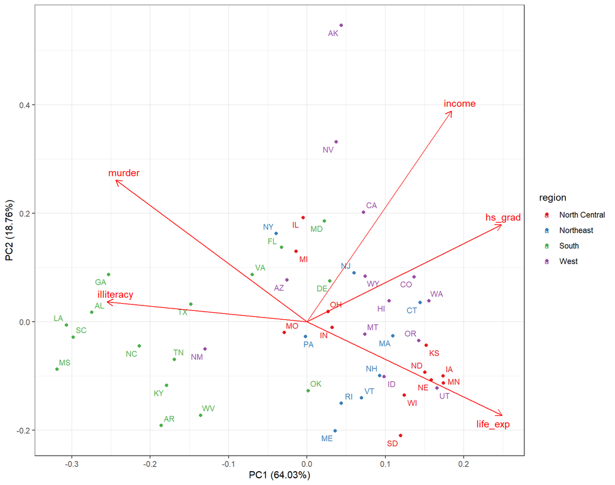

**Figure 1:** Principal components analysis of income, illiteracy, life expectancy (life_exp), murder, and high-school graduation percentage (hs_grad) across the 50 states of the US. Four different label colors represent geographical regions. PC1 accounts for 64.03% of the variance in the data, while PC2 accounts for 18.76%. Together the two principal components account for 82.79% of the variance. Data: R. A. Becker, et al.

```r
#create palette
state_palette <- c("#7A871E", "#104210", "#E55B13", "#F6A21E")

#create the PCA plot
states_pca <- states_df %>%
  select(income, illiteracy, life_exp, murder, hs_grad) %>%
  scale() %>%
  prcomp()

autoplot(states_pca,
         data = states_df,
         label.size = 3,
         colour = 'region',
         loadings = TRUE,
         loadings.label = TRUE,
         loadings.label.repel = TRUE,
         label.repel = TRUE) +
  scale_color_brewer(palette = "Set1") +
  theme_bw()
```

### Discussion

Based on this principal components analysis biplot, we can see that a large amount of variance in the data is preserved by the first two principal components. PC1 accounts for 64.03% of the variance in the data, while PC2 accounts for 18.76%. Together the two principal components account for 82.79% of the variance.

The original dataset (`state.x77`) contained several other variables that were not included in the PCA:

- `population`: population estimate as of July 1, 1975
- `frost`: mean number of days with minimum temperaure below freezing (1931-1960) in capital or large city
- `Area`: land area in square miles

An added `density` variable was calculated by dividing `population` by `area`. These variables were tested using the PCA analysis but the two principal components together did not yield a threshold explained variance of 80%. From an intuitive standpoint, these figures seem less correlated with the others so were ommitted from the final output.

The key takeaways from the principal components analysis biplot and loadings are as follows:

- State murder rate is negatively correlated with life expectancy.
- Per capita income is not correlated with either murder rate or life expectancy.
- The percentage of the population that graduated high school is somewhat positively correlated with per capita income.
- Illiteracy of the population is somewhat negatively correlated with the percentage of the population that graduated high school.
- Murder rate is somewhat positively correlated with illiteracy.

Looking at the positions of the states along the biplot and loadings, we can surmise certain trends in the data. There is a clustering of southern states to the left of the plot which suggests a higher level of illiteracy. For example, based on Georgia’s (GA) position, we might predict a higher level of illiteracy but also a higher murder rate. Interestingly, there is a clustering of north central states to the lower right of the biplot, suggesting higher life expectancy and lower murder rates in those states. California (CA), Nevada (NV), and Alaska (AK) are higher up on the graph suggesting higher levels of per capita income. Many other western states with a mix of northeastern states are clustered around the high school graduation eigenvector, which implies higher levels of high school graduation in those states.

### Data Citations

**Source:**

U.S. Department of Commerce, Bureau of the Census (1977) Statistical Abstract of the United States.

U.S. Department of Commerce, Bureau of the Census (1977) County and City Data Book.

**References:**

Becker, R. A., Chambers, J. M. and Wilks, A. R. (1988) The New S Language. Wadsworth & Brooks/Cole.